# Random Data and Exploratory Data Analysis

## Random data

6면체 주사위를 10번 던졌을 때 나타나는 결과 출력하기. (단, 복원추출)

```r
sample(1:6, 10, replace = T)
```

```
##  [1] 5 6 1 5 2 1 3 2 5 1
```

RollDie라는 함수를 만들어서 6면체 주사위를 5번 던졌을 때 나타나는 결과 출력하기. (단, 복원추출)

```r
RollDie = function(n) sample(1:6, n, replace = T)
RollDie(5)
```

```
## [1] 2 5 2 4 4
```

균일분포를 따르는 난수생성하기. (X~Uniform(a,b))  
(난수를 생성할 시에는 r이라는 문구를 함수앞에 붙인다.)

```r
runif(1, 0, 2)  # time at light
```

```
## [1] 1.298
```

```r
runif(5, 0, 2)  # time at 5 lights
```

```
## [1] 1.9107 1.7046 0.7251 0.5245 0.2462
```

```r
runif(5)  # 5 random numbers in [0,1] (구간을 지정하지 않는 경우에는 기본적으로 구간 [0,1]에 대한 균일분포를 R이 고려한다.)
```

```
## [1] 0.6074 0.7284 0.2499 0.4648 0.6674
```

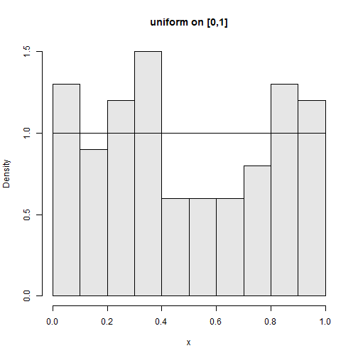

```r
x = runif(100)  # get the random numbers
hist(x, probability = TRUE, col = gray(0.9), main = "uniform on [0,1]")  # 확률을 이용하여 히스토그램 그리기
curve(dunif(x, 0, 1), add = T)  # 균일분포의 그래프 그리기
```

정규분포를 따르는 난수생성하기. (X~Normal(μ,σ²))

```r
rnorm(1, 100, 16)  # an IQ score
```

```
## [1] 98.34
```

```r
rnorm(1, mean = 280, sd = 10)
```

```
## [1] 293
```

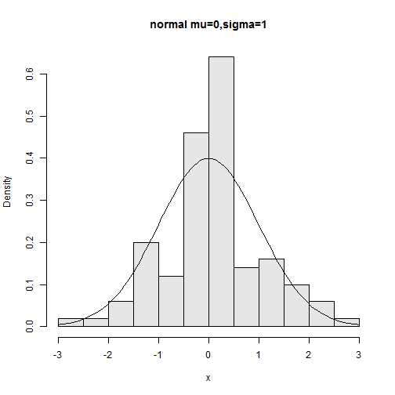

```r
x = rnorm(100)  # 평균과 표준편차를 지정하지 않을시 R에서는 표준정규분포를 고려한다.
hist(x, probability = TRUE, col = gray(0.9), main = "normal mu=0,sigma=1")  # 확률을 이용하여 히스토그램 그리기
curve(dnorm(x), add = T)  # 표준정규분포 곡선 그리기
```

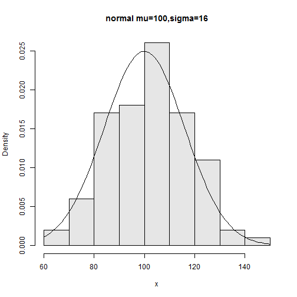

```r
## also for IQs using rnorm(100,mean=100,sd=16)
x = rnorm(100, 100, 16)
hist(x, probability = TRUE, col = gray(0.9), main = "normal mu=100,sigma=16")
curve(dnorm(x, 100, 16), add = T)
```

이항분포를 따르는 난수생성하기. (X~Binomial(n,p))

```r
n = 1
p = 0.5  # set the probability
rbinom(1, n, p)  # different each time (n은 시행횟수, p는 성공의 확률)
```

```
## [1] 0
```

```r
rbinom(10, n, p)  # 10 different such numbers
```

```
##  [1] 1 1 1 0 1 1 1 0 1 0
```

```r
n = 10
p = 0.5
rbinom(1, n, p)  # 6 successes in 10 trials
```

```
## [1] 7
```

```r
rbinom(5, n, p)  # 5 binomial number
```

```
## [1] 6 5 5 3 3
```

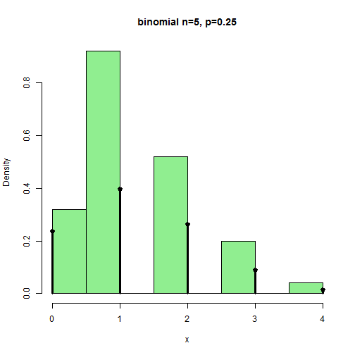

```r
n = 5
p = 0.25  # change as appropriate
x = rbinom(100, n, p)
hist(x, probability = TRUE, col = "lightgreen", main = "binomial n=5, p=0.25")
## use points, not curve as dbinom wants integers only for x
xvals = 0:n
points(xvals, dbinom(xvals, n, p), type = "h", lwd = 3)  # 각각에 대한 확률을 선높이로 표현.
points(xvals, dbinom(xvals, n, p), type = "p", lwd = 3)  # 선위에 점찍기.
```

지수분포를 따르는 난수생성하기. (X~Exp(λ))

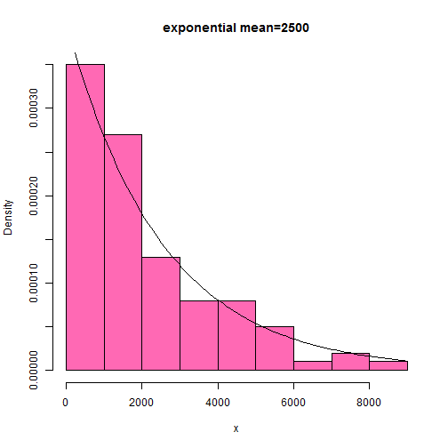

```r
x = rexp(100, 1/2500)
hist(x, probability = TRUE, col = "hotpink", main = "exponential mean=2500")
curve(dexp(x, 1/2500), add = T)
```

주사위 던지기, 동전 던지기, 카드놀이에서 나타나는 각각의 결과들 중에서 표본 추출하기.

```r
## Roll a die (6면체 주사위 던지기)
sample(1:6, 10, replace = TRUE)
```

```
##  [1] 3 4 2 1 3 3 1 5 6 4
```

```r
## toss a coin (동전 던지기)
sample(c("H", "T"), 10, replace = TRUE)
```

```
##  [1] "H" "H" "T" "T" "H" "T" "H" "T" "T" "H"
```

```r
## pick 6 of 54 (a lottery)
sample(1:54, 6)  # no replacement
```

```
## [1] 35 13 28 33  8 17
```

```r
## pick a card. (Fancy! Uses paste, rep) (카드 놀이)
cards = paste(rep(c("A", 2:10, "J", "Q", "K"), 4), c("H", "D", "S", "C"))
cards
```

```
##  [1] "A H"  "2 D"  "3 S"  "4 C"  "5 H"  "6 D"  "7 S"  "8 C"  "9 H"  "10 D"
## [11] "J S"  "Q C"  "K H"  "A D"  "2 S"  "3 C"  "4 H"  "5 D"  "6 S"  "7 C"
## [21] "8 H"  "9 D"  "10 S" "J C"  "Q H"  "K D"  "A S"  "2 C"  "3 H"  "4 D"
## [31] "5 S"  "6 C"  "7 H"  "8 D"  "9 S"  "10 C" "J H"  "Q D"  "K S"  "A C"
## [41] "2 H"  "3 D"  "4 S"  "5 C"  "6 H"  "7 D"  "8 S"  "9 C"  "10 H" "J D"
## [51] "Q S"  "K C"
```

```r
sample(cards, 5)  # a pair of jacks, no replacement
```

```
## [1] "K D" "A D" "5 S" "7 C" "K S"
```

```r
## roll 2 die. Even fancier (두개의 주사위 던지기)
dice = as.vector(outer(1:6, 1:6, paste))
dice
```

```
##  [1] "1 1" "2 1" "3 1" "4 1" "5 1" "6 1" "1 2" "2 2" "3 2" "4 2" "5 2"
## [12] "6 2" "1 3" "2 3" "3 3" "4 3" "5 3" "6 3" "1 4" "2 4" "3 4" "4 4"
## [23] "5 4" "6 4" "1 5" "2 5" "3 5" "4 5" "5 5" "6 5" "1 6" "2 6" "3 6"
## [34] "4 6" "5 6" "6 6"
```

```r
sample(dice, 5, replace = TRUE)  # replace when rolling dice
```

```
## [1] "3 2" "3 3" "5 5" "4 6" "1 1"
```

faithful이라는 데이터를 이용하여 표본 추출 및 히스토그램 그리기.

```r
data(faithful)  # part of R's base
names(faithful)  # find the names for faithful
```

```
## [1] "eruptions" "waiting"
```

```r
eruptions = faithful[["eruptions"]]  # or attach and detach faithful
sample(eruptions, 10, replace = TRUE)
```

```
##  [1] 4.583 2.000 4.500 3.367 2.800 4.400 2.300 4.817 1.933 2.383
```

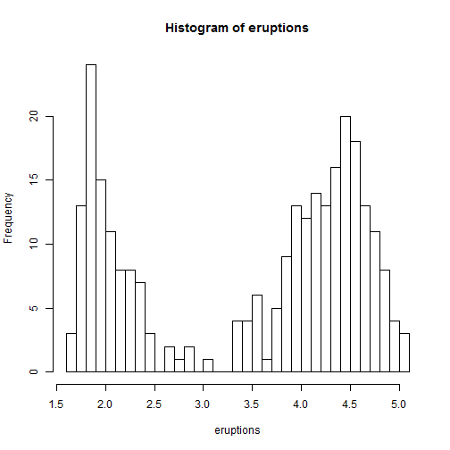

```r
hist(eruptions, breaks = 25)  # the dataset
```

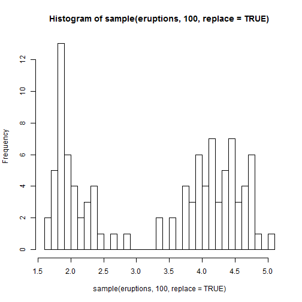

```r
## the bootstrap sample
hist(sample(eruptions, 100, replace = TRUE), breaks = 25)
```

p : cdf를 구할 때 사용 , q : cdf의 역함수

```r
pnorm(0.7)  # standard normal ( P(Z ? 0.7) 계산하기 )
```

```
## [1] 0.758
```

```r
pnorm(0.7, 1, 1)  # normal mean 1, std 1
```

```
## [1] 0.3821
```

```r
pnorm(0.7, lower.tail = F)  # ( P(Z > 0.7) 계산하기 )
```

```
## [1] 0.242
```

```r
qnorm(0.75)
```

```
## [1] 0.6745
```

확률변수의 표준화 (Z=(X-μ)/σ)

```r
x = rnorm(5, 100, 16)
x
```

```
## [1] 121.28  84.11 119.58  97.90  99.21
```

```r
z = (x - 100)/16
z
```

```
## [1]  1.32981 -0.99308  1.22373 -0.13109 -0.04916
```

```r
pnorm(z)
```

```
## [1] 0.9082 0.1603 0.8895 0.4479 0.4804
```

```r
pnorm(x, 100, 16)  # enter in parameters
```

```
## [1] 0.9082 0.1603 0.8895 0.4479 0.4804
```

## Exploratory Data Analysis

간단한 히스토그램 2개 그리기.

```r
library("UsingR")
```

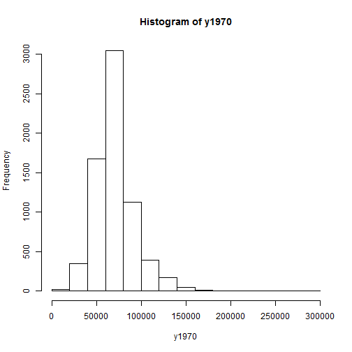

```r
data(homedata)  # from UsingR package
attach(homedata)
hist(y1970)
```

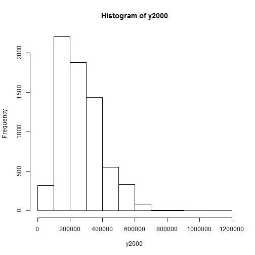

```r
hist(y2000)  # make two histograms
```

```r
detach(homedata)
```

simple.eda >> 자료에 대한 요약정리를 보고싶을 때 사용.

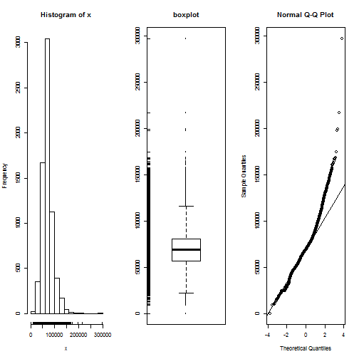

```r
attach(homedata)
simple.eda(y1970)
```

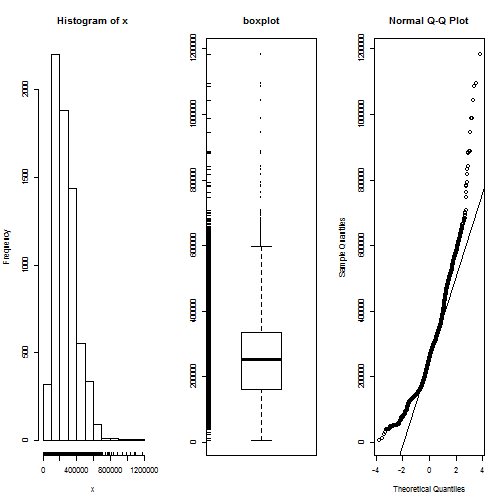

```r
simple.eda(y2000)
```

```r
detach(homedata)  # clean up
```

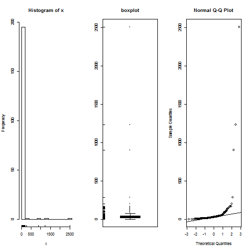

```r
data(exec.pay)  # or read in from file
simple.eda(exec.pay)
```

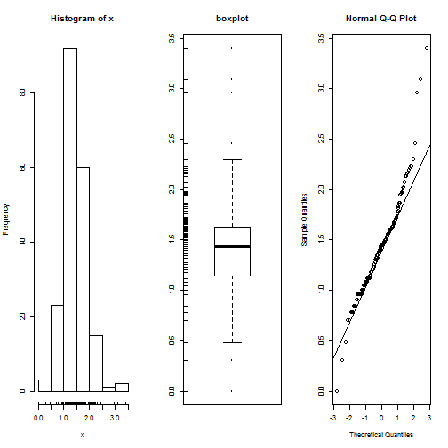

```r
log.exec.pay = log(exec.pay[exec.pay > 0])/log(10)  # 0 is a problem
simple.eda(log.exec.pay)
```

데이터 ewr에 대한 분석시도.

```r
data(ewr)
ewr
```

```
##    Year Month   AA   CO   DL   HP   NW   TW   UA   US inorout
## 1  2000   Nov  8.6  8.3  8.6 10.4  8.1  9.1  8.4  7.6      in
## 2  2000   Oct  8.5  8.0  8.4 11.2  8.2  8.5  8.5  7.8      in
## 3  2000   Sep  8.1  8.5  8.4 10.2  8.3  8.6  8.2  7.6      in
## 4  2000   Aug  8.9  9.1  9.2 14.5  9.0 10.3  9.2  8.7      in
## 5  2000   Jul  8.3  8.9  8.2 11.5  8.8  9.1  9.2  8.2      in
## 6  2000   Jun  8.8  9.0  8.8 14.9  8.4 10.8  8.9  8.3      in
## 7  2000   May  8.1  8.8  7.9  9.8  7.8  7.5  8.1  8.3      in
## 8  2000   Apr  8.7  8.6  8.1  9.8  8.6  8.1  8.5  9.5      in
## 9  2000   Mar  8.8  8.4  7.8  8.0  8.7  6.4  8.2  7.9      in
## 10 2000   Feb  8.7  8.9  7.6  9.3  8.5  6.9  8.2  7.5      in
## 11 2000   Jan  9.4  9.4  8.5  9.9  9.4  6.3  8.6  7.7      in
## 12 1999   Dec  8.6  8.7  7.8  9.3  8.1  6.0  7.8  7.1      in
## 13 1999   Nov  8.3  9.3  8.5 10.4  8.9  6.1  8.0  7.1      in
## 14 1999   Oct  7.9  9.4  8.1 10.8  9.3  5.9  8.0  7.2      in
```

[output cut: 32 more lines]

```r
names(ewr)  # only 3-10 are raw data
```

```
##  [1] "Year"    "Month"   "AA"      "CO"      "DL"      "HP"      "NW"
##  [8] "TW"      "UA"      "US"      "inorout"
```

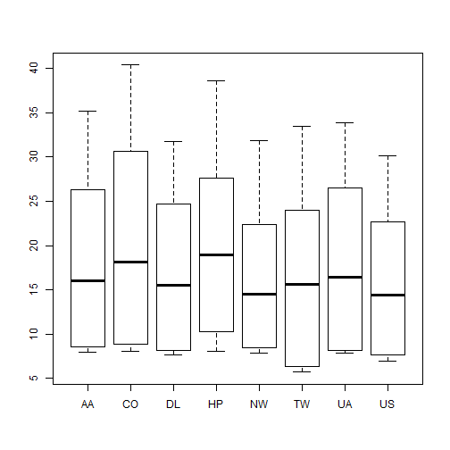

```r
airnames = names(ewr)  # store them for later
ewr.actual = ewr[, 3:10]  # get the important columns
boxplot(ewr.actual)
```

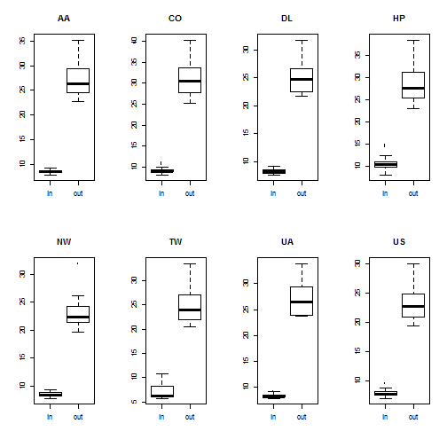

```r
par(mfrow = c(2, 4))  # 2 rows 4 columns
attach(ewr)
for (i in 3:10) boxplot(ewr[, i] ~ as.factor(inorout), main = airnames[i])
```

```r
detach(ewr)
par(mfrow = c(1, 1))  # return graphics as is (or close window)
```

여러가지 확률분포들에 대한 난수를 생성하고 상자그림 그리기.

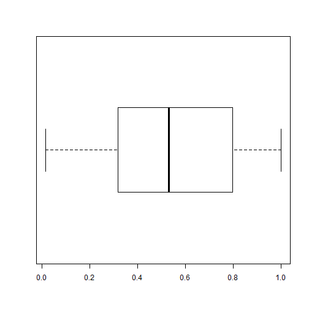

```r
## symmetric: short, regular then long
X = runif(100)
boxplot(X, horizontal = T, bty = n)  # 구간 [0,1]을 취하는 균일분포
```

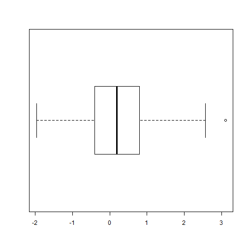

```r
X = rnorm(100)
boxplot(X, horizontal = T, bty = n)  # 표준정규분포
```

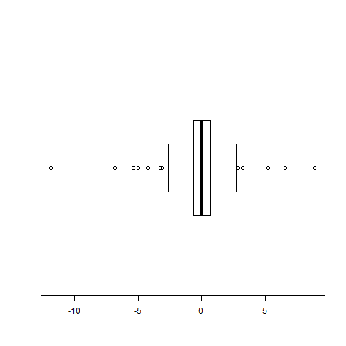

```r
X = rt(100, 2)
boxplot(X, horizontal = T, bty = n)  # 자유도가 2인 t분포
```

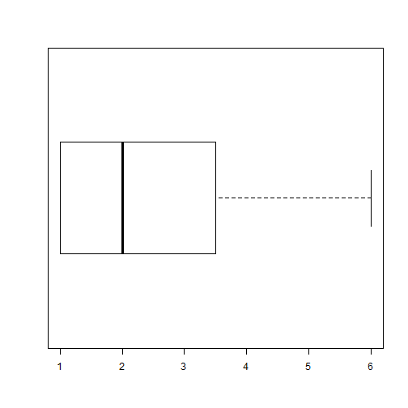

```r
## skewed: short, regular then long triangle distribution
X = sample(1:6, 100, p = 7 - (1:6), replace = T)
boxplot(X, horizontal = T, bty = n)
```

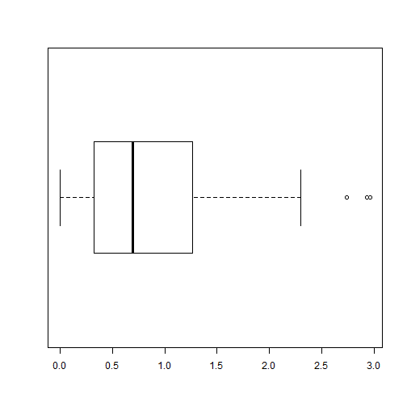

```r
X = abs(rnorm(200))
boxplot(X, horizontal = T, bty = n)
```

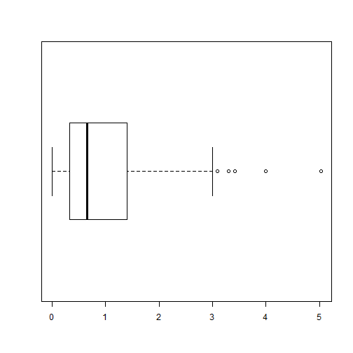

```r
X = rexp(200)
boxplot(X, horizontal = T, bty = n)  # λ=1 인 지수분포
```